# Diet_EDA

Hilal Pajo

2024-12-13

#📖INTRODUCTION This study aims to understand the effects of individuals’ stress level, sleep quality, age, gender and other factors on weight change. The aim of this analysis is to create a model that can predict weight change. For this purpose, answers were sought to questions such as: What are the relationship among provided factors and visualization of results? What are the variables that best explain weight change? Is there a regression model that can predict weight change?

🏥This analysis can be beneficial for health professionals, nutritionists, and individuals seeking to understand the key factors influencing weight change and develop more personalized health and wellness strategies.

💻This project was conducted to showcase my data analysis skills, and while the insights are valuable, the findings could be further strengthened with a larger sample size. Additionally, the analysis could be expanded with alternative perspectives and methods, reflecting the dynamic nature of data analysis.

#ABOUT THIS FILE

📌Participant ID: Unique identifier for each participant in the study.

📌Age: The age of the participant (in years), which can influence metabolism and weight change.

📌Gender: Gender of the participant (M/F), as physiological differences may affect weight management.

📌Current Weight (lbs): The participant’s weight at the beginning of the study, serving as a baseline for weight change.

📌BMR (Calories): Basal Metabolic Rate, calculated using the Mifflin-St Jeor equation, representing the number of calories burned at rest.

📌Daily Calories Consumed: Total caloric intake per day, including variability to reflect real-world eating habits.

📌Daily Caloric Surplus/Deficit: The difference between calories consumed and BMR, indicating whether the participant is in a caloric surplus or deficit.

📌Weight Change (lbs): The estimated change in weight over a specified duration, based on caloric surplus/deficit.

📌Duration (weeks): The time period over which weight change is measured, ranging from 1 to 12 weeks.

📌Physical Activity Level: Self-reported level of physical activity, categorized as Sedentary, Lightly Active, Moderately Active, or Very Active.

📌Sleep Quality: Self-reported quality of sleep, categorized as Poor, Fair, Good, or Excellent, which can affect weight management.

📌Stress Level: A numerical score (1-10) indicating the participant’s perceived stress level, as stress can influence eating behaviors and weight.

```r
diet_csv <- read.csv("C:/Users/90544/Documents/project portfolio/Diet analysis, predict the weight/weight_change_dataset.csv")
head(diet_csv)
```

```
##   Participant.ID Age Gender Current.Weight..lbs. BMR..Calories.
## 1              1  56      M                228.4         3102.3
## 2              2  46      F                165.4         2275.5
## 3              3  32      F                142.8         2119.4
## 4              4  25      F                145.5         2181.3
## 5              5  38      M                155.5         2463.8
## 6              6  56      F                152.9         2100.6
##   Daily.Calories.Consumed Daily.Caloric.Surplus.Deficit Weight.Change..lbs.
## 1                  3916.0                         813.7              0.2000
## 2                  3823.0                        1547.5              2.4000
## 3                  2785.4                         666.0              1.4000
## 4                  2587.3                         406.0              0.8000
## 5                  3312.8                         849.0              2.0000
## 6                  2262.4                         161.9            -12.5135
##   Duration..weeks. Physical.Activity.Level Sleep.Quality Stress.Level
## 1                1               Sedentary     Excellent            6
## 2                6             Very Active     Excellent            6
## 3                7               Sedentary          Good            3
## 4                8               Sedentary          Fair            2
## 5               10          Lightly Active          Good            1
## 6                9               Sedentary          Poor            6
##   Final.Weight..lbs.
## 1              228.6
## 2              167.8
## 3              144.2
## 4              146.3
## 5              157.5
## 6              140.4
```

#data cleaning for quality purposes

```r
sum(is.na(diet_csv))
```

```
## [1] 0
```

```r
colSums(is.na(diet_csv))
```

```
##                Participant.ID                           Age
##                             0                             0
##                        Gender          Current.Weight..lbs.
##                             0                             0
##                BMR..Calories.       Daily.Calories.Consumed
##                             0                             0
## Daily.Caloric.Surplus.Deficit           Weight.Change..lbs.
##                             0                             0
##              Duration..weeks.       Physical.Activity.Level
##                             0                             0
##                 Sleep.Quality                  Stress.Level
##                             0                             0
##            Final.Weight..lbs.
##                             0
```

#Data validation step complete: No missing values detected, ensuring data quality. Next steps include exploring potential outliers and inconsistencies.

#summary statistics to understand the data

```r
summary(diet_csv)
```

```
##  Participant.ID        Age           Gender          Current.Weight..lbs.
##  Min.   :  1.00   Min.   :18.00   Length:100         Min.   :100.0
##  1st Qu.: 25.75   1st Qu.:26.75   Class :character   1st Qu.:153.7
##  Median : 50.50   Median :38.00   Mode  :character   Median :172.2
##  Mean   : 50.50   Mean   :37.91                      Mean   :171.5
##  3rd Qu.: 75.25   3rd Qu.:46.25                      3rd Qu.:192.5
##  Max.   :100.00   Max.   :59.00                      Max.   :238.2
##  BMR..Calories. Daily.Calories.Consumed Daily.Caloric.Surplus.Deficit
##  Min.   :1566   Min.   :2031            Min.   :  82.5
##  1st Qu.:2255   1st Qu.:3233            1st Qu.: 767.0
##  Median :2520   Median :3636            Median :1013.1
##  Mean   :2518   Mean   :3518            Mean   :1000.1
##  3rd Qu.:2806   3rd Qu.:4000            3rd Qu.:1253.3
##  Max.   :3391   Max.   :4000            Max.   :1922.5
##  Weight.Change..lbs. Duration..weeks. Physical.Activity.Level
##  Min.   :-35.678     Min.   : 1.00    Length:100
##  1st Qu.: -5.012     1st Qu.: 4.00    Class :character
##  Median :  0.100     Median : 7.00    Mode  :character
##  Mean   : -2.780     Mean   : 6.92
##  3rd Qu.:  1.850     3rd Qu.:10.00
##  Max.   :  5.000     Max.   :12.00
##  Sleep.Quality       Stress.Level  Final.Weight..lbs.
##  Length:100         Min.   :1.00   Min.   : 98.2
##  Class :character   1st Qu.:2.75   1st Qu.:149.6
##  Mode  :character   Median :5.00   Median :169.8
##                     Mean   :4.81   Mean   :168.8
##                     3rd Qu.:7.00   3rd Qu.:188.3
##                     Max.   :9.00   Max.   :232.5
```

```r
prop.table(table(diet_csv$Gender))
```

```
##
##    F    M
## 0.43 0.57
```

```r
prop.table(table(diet_csv$Physical.Activity.Level))
```

```
##
##    Lightly Active Moderately Active         Sedentary       Very Active
##              0.31              0.25              0.21              0.23
```

```r
prop.table(table(diet_csv$Sleep.Quality))
```

```
##
## Excellent      Fair      Good      Poor
##      0.16      0.24      0.22      0.38
```

#examining categorical variables

```r
table(diet_csv$Gender)
```

```
##
##  F  M
## 43 57
```

```r
table(diet_csv$Physical.Activity.Level)
```

```
##
##    Lightly Active Moderately Active         Sedentary       Very Active
##                31                25                21                23
```

```r
table(diet_csv$Sleep.Quality)
```

```
##
## Excellent      Fair      Good      Poor
##        16        24        22        38
```

```r
str(diet_csv)
```

```
## 'data.frame':    100 obs. of  13 variables:
##  $ Participant.ID               : int  1 2 3 4 5 6 7 8 9 10 ...
##  $ Age                          : int  56 46 32 25 38 56 36 40 28 28 ...
##  $ Gender                       : chr  "M" "F" "F" "F" ...
##  $ Current.Weight..lbs.         : num  228 165 143 146 156 ...
##  $ BMR..Calories.               : num  3102 2276 2119 2181 2464 ...
##  $ Daily.Calories.Consumed      : num  3916 3823 2785 2587 3313 ...
##  $ Daily.Caloric.Surplus.Deficit: num  814 1548 666 406 849 ...
##  $ Weight.Change..lbs.          : num  0.2 2.4 1.4 0.8 2 ...
##  $ Duration..weeks.             : int  1 6 7 8 10 9 2 11 10 2 ...
##  $ Physical.Activity.Level      : chr  "Sedentary" "Very Active" "Sedentary" "Sedentary" ...
##  $ Sleep.Quality                : chr  "Excellent" "Excellent" "Good" "Fair" ...
##  $ Stress.Level                 : int  6 6 3 2 1 6 5 9 1 7 ...
##  $ Final.Weight..lbs.           : num  229 168 144 146 158 ...
```

#Calculate the correlation matrix to understand relationships between numeric features.

```r
numeric_columns <- sapply(diet_csv, is.numeric)
correlation_matrix <- cor(diet_csv[, numeric_columns])
print(round (correlation_matrix, 2))
```

```
##                               Participant.ID   Age Current.Weight..lbs.
## Participant.ID                          1.00  0.00                -0.04
## Age                                     0.00  1.00                -0.02
## Current.Weight..lbs.                   -0.04 -0.02                 1.00
## BMR..Calories.                         -0.04 -0.20                 0.93
## Daily.Calories.Consumed                 0.02 -0.09                 0.61
## Daily.Caloric.Surplus.Deficit           0.07  0.06                -0.07
## Weight.Change..lbs.                    -0.01  0.06                -0.09
## Duration..weeks.                        0.20 -0.09                -0.02
## Stress.Level                            0.14  0.02                -0.06
## Final.Weight..lbs.                     -0.04 -0.01                 0.97
##                               BMR..Calories. Daily.Calories.Consumed
## Participant.ID                         -0.04                    0.02
## Age                                    -0.20                   -0.09
## Current.Weight..lbs.                    0.93                    0.61
## BMR..Calories.                          1.00                    0.69
## Daily.Calories.Consumed                 0.69                    1.00
## Daily.Caloric.Surplus.Deficit          -0.03                    0.70
## Weight.Change..lbs.                    -0.11                   -0.06
## Duration..weeks.                        0.00                    0.06
## Stress.Level                           -0.07                    0.00
## Final.Weight..lbs.                      0.90                    0.59
##                               Daily.Caloric.Surplus.Deficit Weight.Change..lbs.
## Participant.ID                                         0.07               -0.01
## Age                                                    0.06                0.06
## Current.Weight..lbs.                                  -0.07               -0.09
## BMR..Calories.                                        -0.03               -0.11
## Daily.Calories.Consumed                                0.70               -0.06
## Daily.Caloric.Surplus.Deficit                          1.00                0.02
## Weight.Change..lbs.                                    0.02                1.00
## Duration..weeks.                                       0.09               -0.14
## Stress.Level                                           0.07               -0.49
## Final.Weight..lbs.                                    -0.06                0.16
##                               Duration..weeks. Stress.Level Final.Weight..lbs.
## Participant.ID                            0.20         0.14              -0.04
## Age                                      -0.09         0.02              -0.01
## Current.Weight..lbs.                     -0.02        -0.06               0.97
## BMR..Calories.                            0.00        -0.07               0.90
## Daily.Calories.Consumed                   0.06         0.00               0.59
## Daily.Caloric.Surplus.Deficit             0.09         0.07              -0.06
## Weight.Change..lbs.                      -0.14        -0.49               0.16
## Duration..weeks.                          1.00         0.01              -0.05
## Stress.Level                              0.01         1.00              -0.17
## Final.Weight..lbs.                       -0.05        -0.17               1.00
```

#creating correlation heatmap to visualize relationships

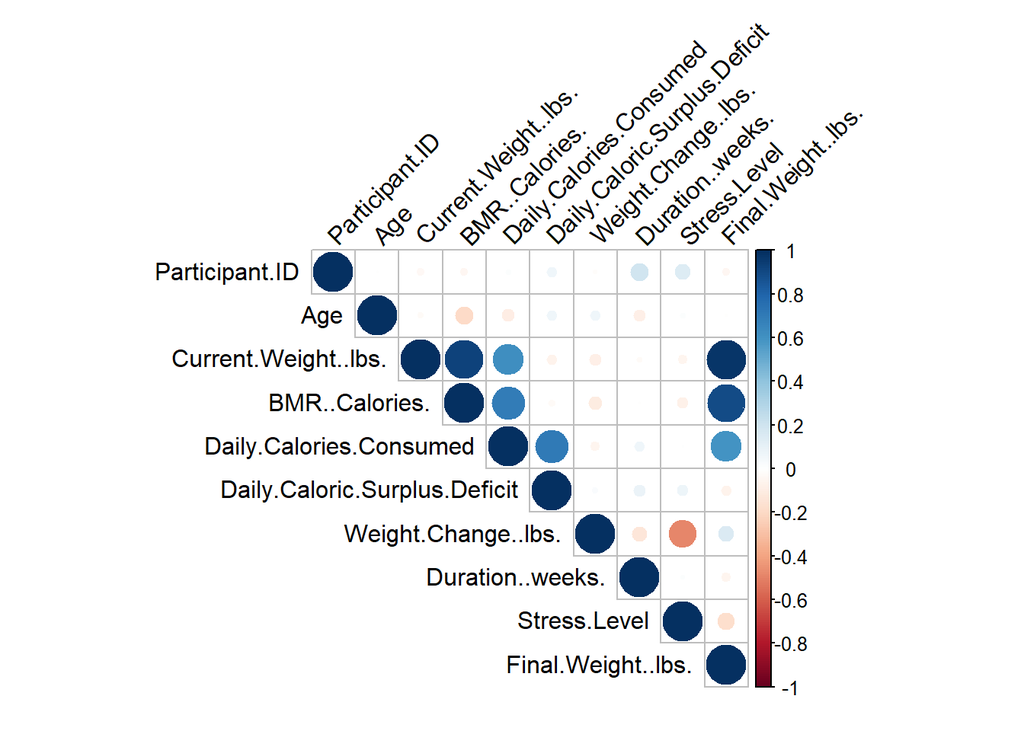

```r
options(repos = c(CRAN = "https://cloud.r-project.org"))

install.packages("corrplot")
library(corrplot)
corrplot(correlation_matrix, method = "circle", type = "upper", tl.col = "black", tl.srt = 45)

library(ggcorrplot)
```

#Current Weight (lbs) and Final Weight (lbs): Current weight and final weight naturally has a relationship current and final weight relationship

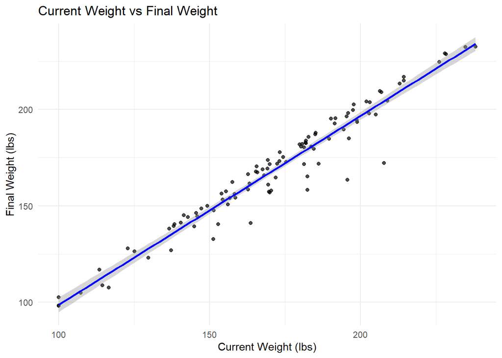

```r
library(ggplot2)
ggplot(diet_csv, aes(x = Current.Weight..lbs., y = Final.Weight..lbs.)) +
  geom_point(alpha = 0.7) +
  geom_smooth(method = "lm", col = "blue") +
  theme_minimal() +
  labs(title = "Current Weight vs Final Weight", x = "Current Weight (lbs)", y = "Final Weight (lbs)")
```

#Stress Level and Weight Change (lbs): Stress has a moderate negative effect on weight lost.

[figure not shown]

```r
ggplot(diet_csv, aes(x = Stress.Level, y = Final.Weight..lbs.)) +
  geom_point(alpha = 0.6) +
  geom_smooth( method = "lm", col = "red") +
  theme_minimal() +
  labs(title = "Stress Level vs Weight Change", x = "Stress Level", y = "Weight Change (lbs)")
```

#Daily calorie intake and weight change relationship

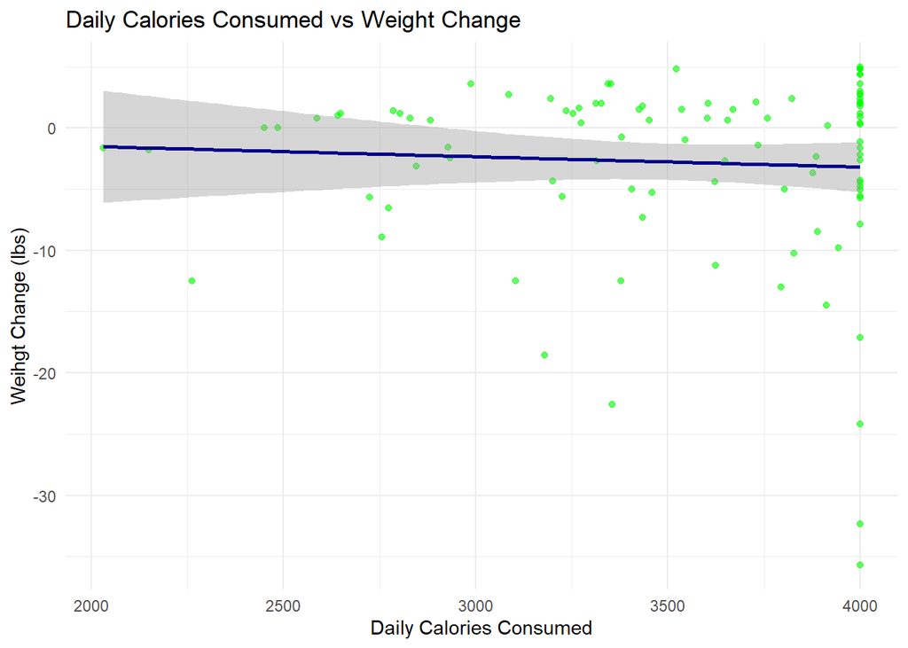

```r
ggplot(diet_csv, aes(x = Daily.Calories.Consumed, y = Weight.Change..lbs.)) +
  geom_point(alpha = 0.6, color = "green" ) +
  geom_smooth(method = "lm", col = "darkblue") +
  theme_minimal () +
  labs(title = "Daily Calories Consumed vs Weight Change", x = "Daily Calories Consumed", y = "Weihgt Change (lbs)")
```

#Explore the relationship between BMR and Current Weight to assess metabolic rate differences.

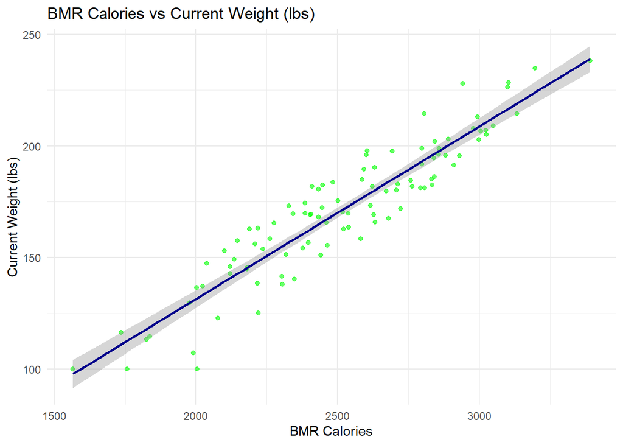

```r
ggplot(diet_csv, aes(x = BMR..Calories., y = Current.Weight..lbs.)) +
  geom_point(alpha = 0.6, color = "green" ) +
  geom_smooth(method = "lm", col = "darkblue") +
  theme_minimal () +
  labs(title = "BMR Calories vs Current Weight (lbs)", x = "BMR Calories", y = "Current Weight (lbs)")
```

#visualization to see the effects of categorical variables #sleep quality

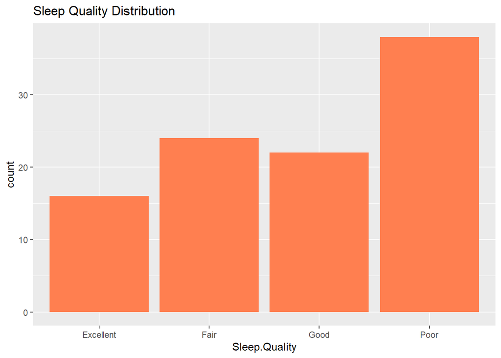

```r
ggplot(diet_csv, aes(x = Sleep.Quality)) +
  geom_bar(fill = "coral") +
  labs(title = "Sleep Quality Distribution")
```

#physical activity level

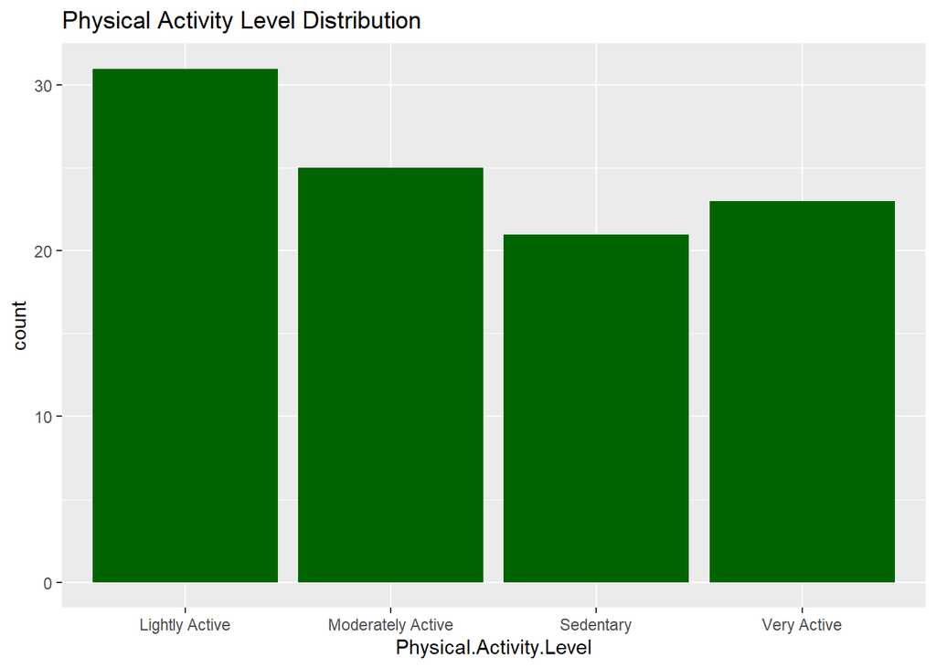

```r
ggplot(diet_csv, aes(x = Physical.Activity.Level)) +
  geom_bar(fill = "darkgreen") +
  labs(title = "Physical Activity Level Distribution")
```

#age

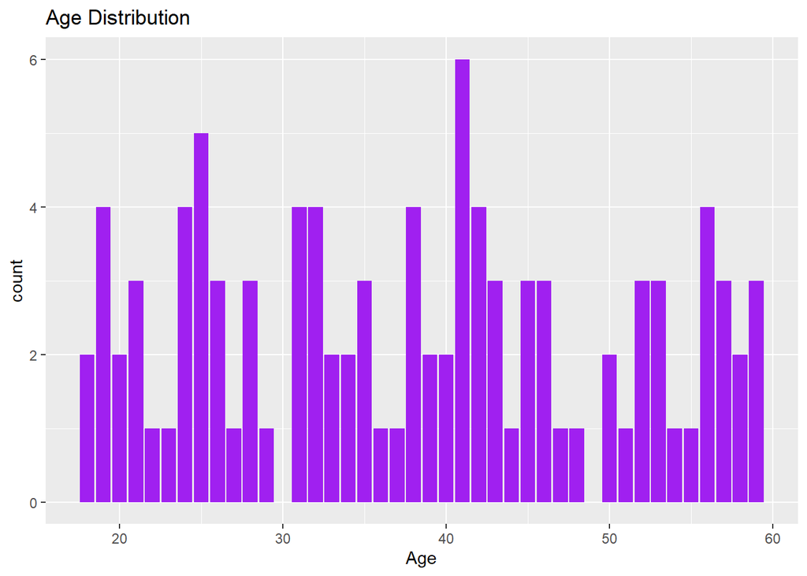

```r
ggplot(diet_csv, aes(x = Age)) +
  geom_bar(fill = "purple") +
  labs(title = "Age Distribution")
```

#which parameters are much related to weight change via regression analysis

```r
model <- lm(Weight.Change..lbs. ~ Age + Stress.Level + Daily.Calories.Consumed + Current.Weight..lbs., data = diet_csv)
summary(model)
```

```
##
## Call:
## lm(formula = Weight.Change..lbs. ~ Age + Stress.Level + Daily.Calories.Consumed +
##     Current.Weight..lbs., data = diet_csv)
##
## Residuals:
##      Min       1Q   Median       3Q      Max
## -26.0004  -2.3758   0.5099   4.4720  11.0544
##
## Coefficients:
##                           Estimate Std. Error t value Pr(>|t|)
## (Intercept)              6.4821746  5.4507090   1.189    0.237
## Age                      0.0437574  0.0541789   0.808    0.421
## Stress.Level            -1.4348383  0.2562407  -5.600 2.08e-07 ***
## Daily.Calories.Consumed  0.0004742  0.0016305   0.291    0.772
## Current.Weight..lbs.    -0.0331574  0.0275220  -1.205    0.231
## ---
## Signif. codes:  0 '***' 0.001 '**' 0.01 '*' 0.05 '.' 0.1 ' ' 1
##
## Residual standard error: 6.551 on 95 degrees of freedom
## Multiple R-squared:  0.2569, Adjusted R-squared:  0.2256
## F-statistic: 8.209 on 4 and 95 DF,  p-value: 9.919e-06
```

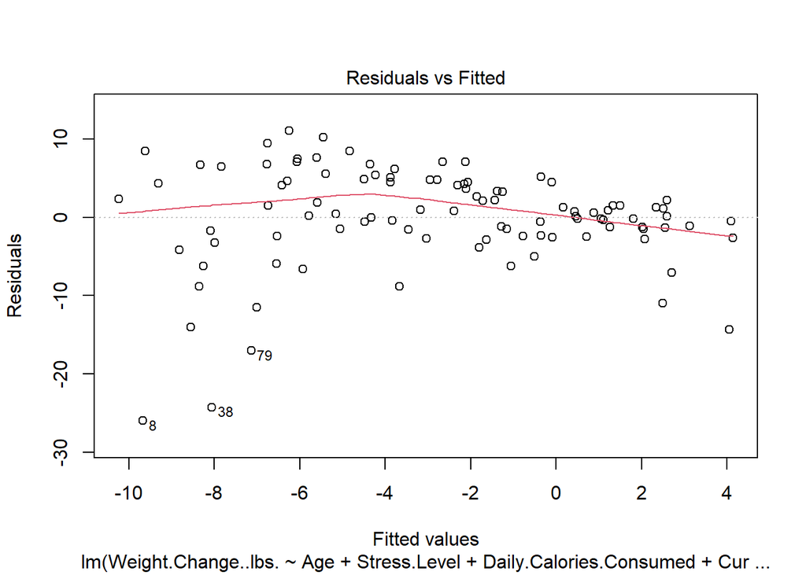

```r
plot(model, which = 1)
```

#Stress level has significant effect on weight change

#Check if weight change significantly differs between genders using ANOVA

```r
result_gender <- aov(Weight.Change..lbs. ~ Gender , data = diet_csv)
summary(result_gender)
```

```
##             Df Sum Sq Mean Sq F value Pr(>F)
## Gender       1     25   24.92   0.447  0.505
## Residuals   98   5461   55.72
```

#Gender does not significantly affect weight change (p = 0.505).

#Check if weight change significantly differs in physical activity level using ANOVA

```r
result_physical <- aov(Weight.Change..lbs. ~ Physical.Activity.Level , data = diet_csv)
summary(result_physical)
```

```
##                         Df Sum Sq Mean Sq F value Pr(>F)
## Physical.Activity.Level  3    135   45.05   0.808  0.492
## Residuals               96   5350   55.73
```

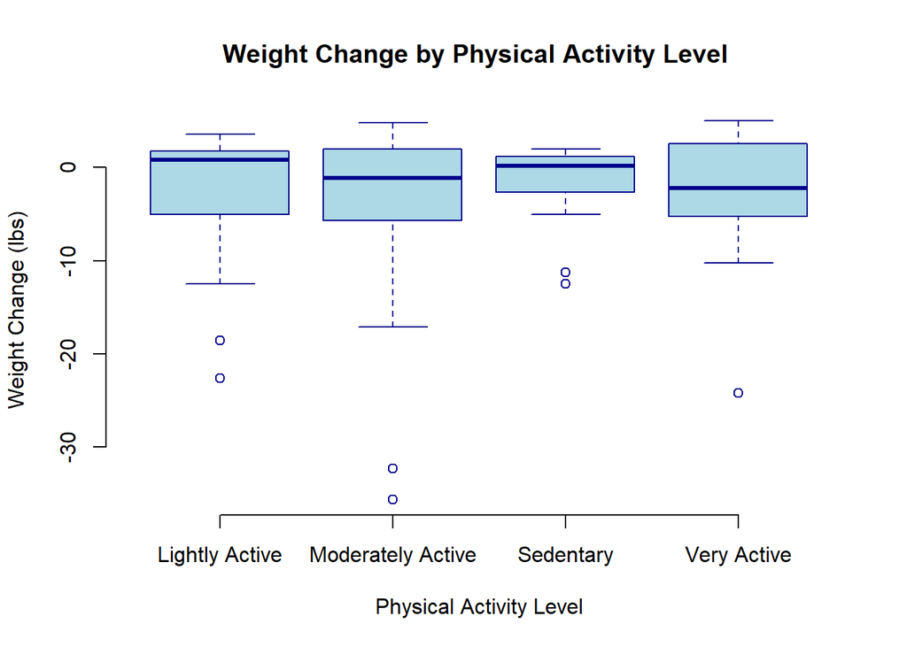

```r
boxplot(Weight.Change..lbs. ~ Physical.Activity.Level , data = diet_csv,
        main = "Weight Change by Physical Activity Level " ,
        xlab = "Physical Activity Level" , ylab = "Weight Change (lbs)",
        col = "lightblue", border = "darkblue", frame = FALSE)
```

#No significant relationship found between physical activity and weight change (potentially due to small sample size).

#Evaluate whether weight change differs significantly by sleep quality using ANOVA.

```r
result_sleep <- aov(Weight.Change..lbs. ~ Sleep.Quality , data = diet_csv)
summary(result_sleep)
```

```
##               Df Sum Sq Mean Sq F value   Pr(>F)
## Sleep.Quality  3   2092   697.5   19.73 4.79e-10 ***
## Residuals     96   3393    35.3
## ---
## Signif. codes:  0 '***' 0.001 '**' 0.01 '*' 0.05 '.' 0.1 ' ' 1
```

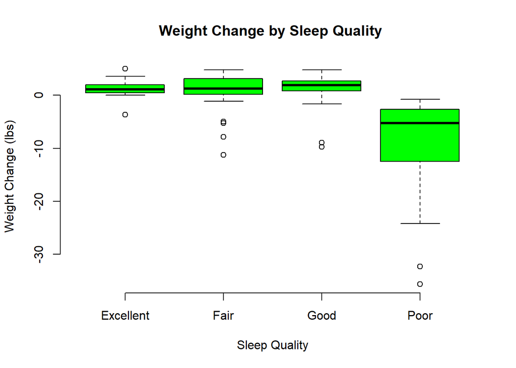

```r
boxplot(Weight.Change..lbs. ~ Sleep.Quality , data = diet_csv,
        main = "Weight Change by Sleep Quality " ,
        xlab = "Sleep Quality" , ylab = "Weight Change (lbs)",
        col = "green" , border = "black" , frame = FALSE)
```

#There is a meaningful relationship between weight change and sleep quality.

#Check if sleep quality significantly differs for daily calories consumed using ANOVA

```r
result_sleepvscalorieconsumed <- aov(Daily.Calories.Consumed ~ Sleep.Quality , data = diet_csv)
summary(result_sleepvscalorieconsumed)
```

```
##               Df   Sum Sq Mean Sq F value Pr(>F)
## Sleep.Quality  3    62774   20925   0.077  0.972
## Residuals     96 26022769  271071
```

#This data does not show a significant relationship between sleep quality and daily calories consumed

#Check if sleep quality significantly differs for final weight using ANOVA

```r
result_sleepvscfinalw <- aov(Final.Weight..lbs. ~ Sleep.Quality , data = diet_csv)
summary(result_sleepvscfinalw)
```

```
##               Df Sum Sq Mean Sq F value Pr(>F)
## Sleep.Quality  3   3313  1104.3   1.187  0.319
## Residuals     96  89314   930.4
```

#We cannot talk about a meaningful relationship between sleep quality and final weight

#Evaluate whether sleep quality differs significantly by stress level using ANOVA.

```r
result_sleepvsstress <- aov(Stress.Level ~ Sleep.Quality , data = diet_csv)
summary(result_sleepvsstress)
```

```
##               Df Sum Sq Mean Sq F value Pr(>F)
## Sleep.Quality  3   19.0   6.323   0.951  0.419
## Residuals     96  638.4   6.650
```

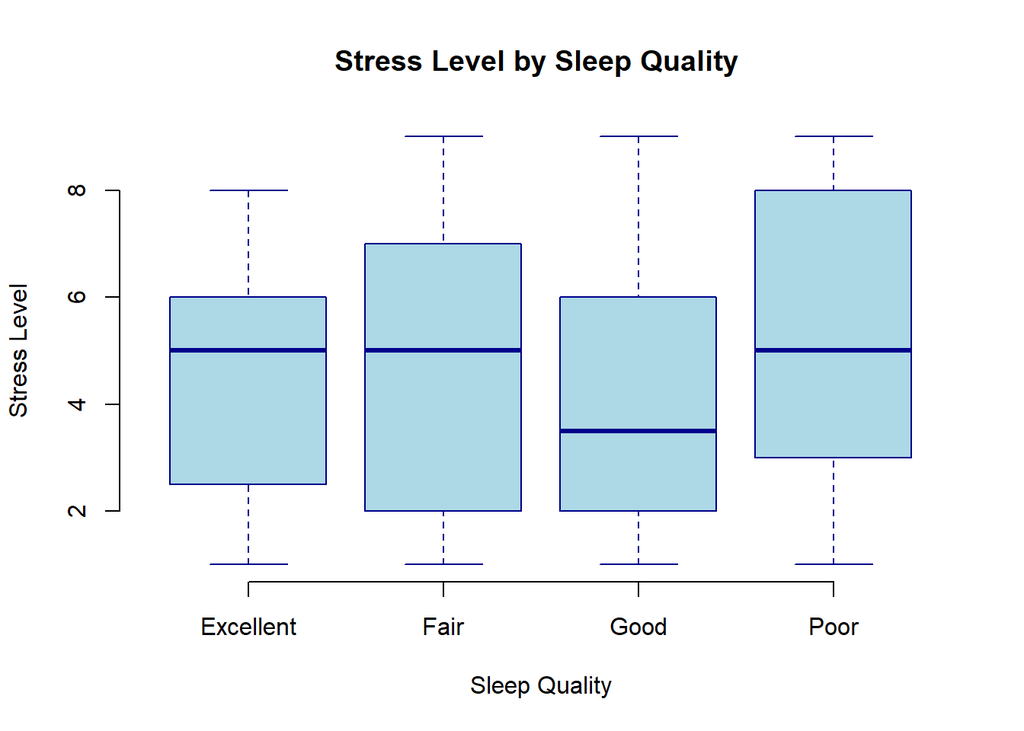

```r
boxplot(Stress.Level ~ Sleep.Quality , data = diet_csv,
        main = "Stress Level by Sleep Quality " ,
        xlab = "Sleep Quality" , ylab = "Stress Level" ,
        col = "lightblue" , border = "darkblue" , frame = FALSE)
```

#Sleep quality is also cannot be explained by stress level as well according to our sample group.

#Histogram Analysis #Plot distribution of weight change to check for skewness and normality.

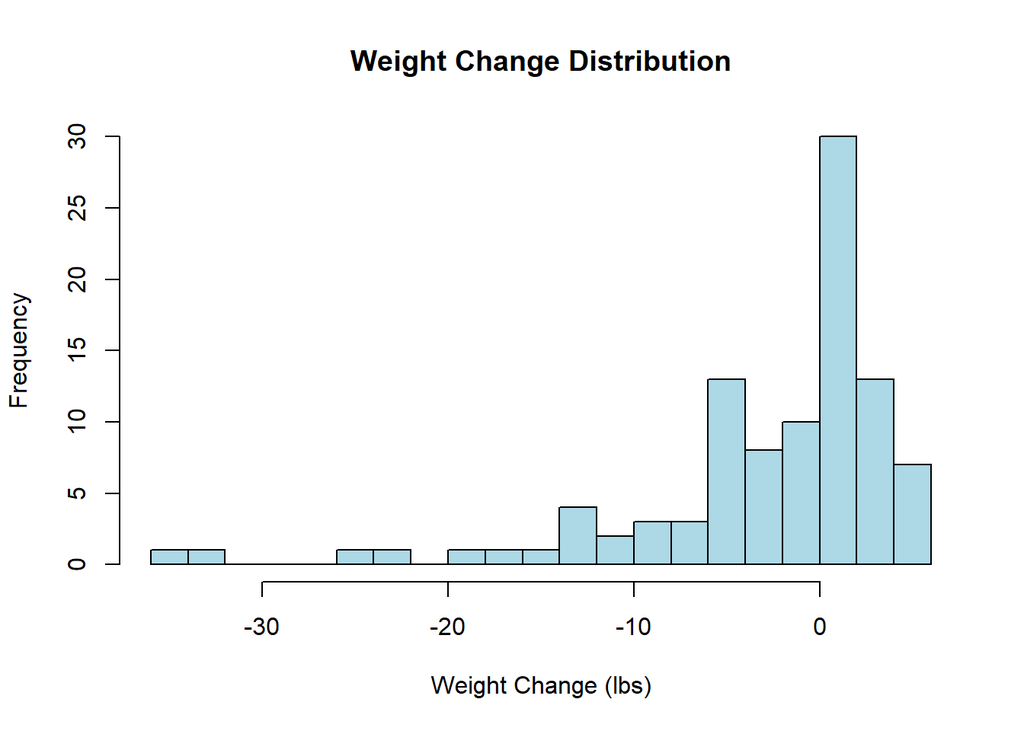

```r
hist(diet_csv$Weight.Change..lbs., breaks = 25, col = "lightblue", main = "Weight Change Distribution" ,
     xlab = "Weight Change (lbs)" )
```

#Plot distribution of age to check for skewness and normality.

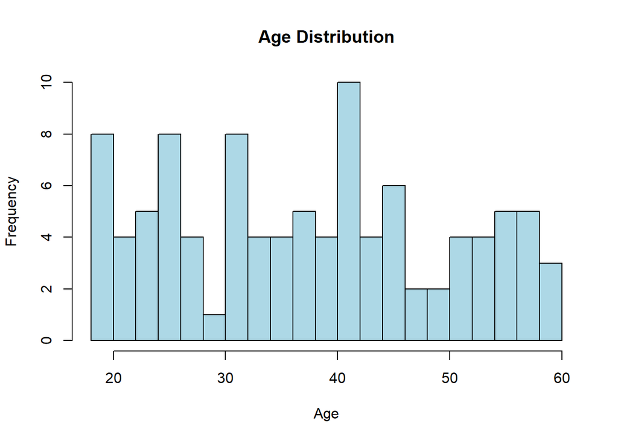

```r
hist(diet_csv$Age , breaks = 15 ,col = "lightblue" , main = "Age Distribution" , xlab = "Age")
```

#Plot distribution of current weight to check for skewness and normality.

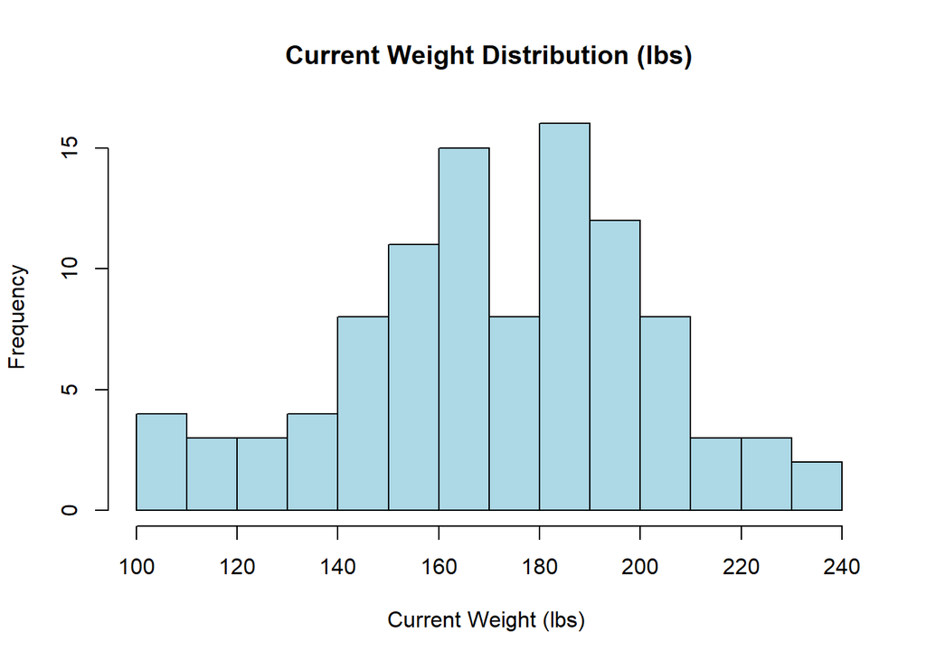

```r
hist(diet_csv$Current.Weight..lbs. , breaks = 15 , col = "lightblue" , main = "Current Weight Distribution (lbs)" ,
     xlab = "Current Weight (lbs) ")
```

#Plot distribution of BMR Calories to check for skewness and normality.

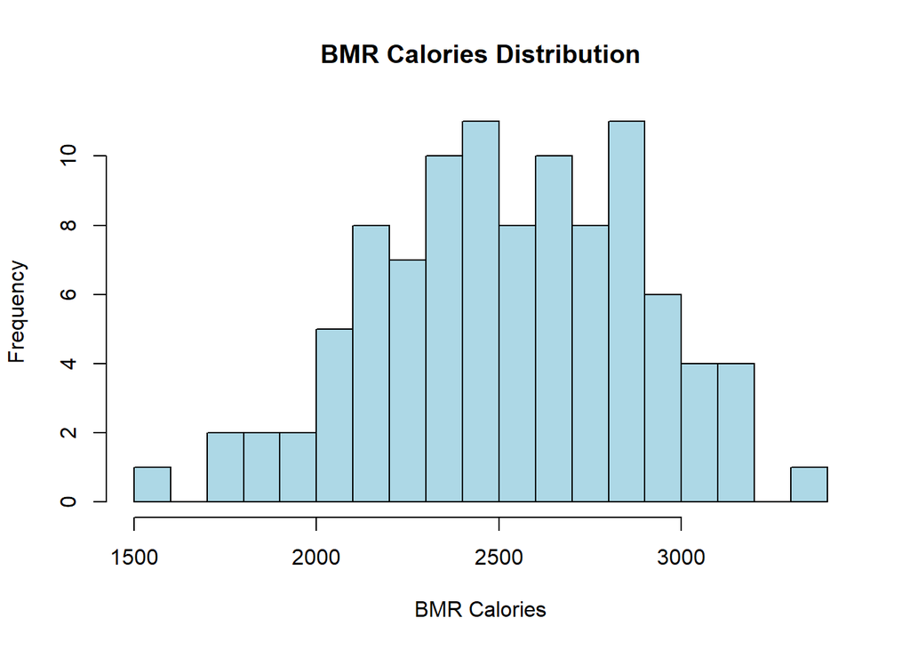

```r
hist(diet_csv$BMR..Calories., breaks = 15 , col = "lightblue", main = "BMR Calories Distribution",
     xlab = "BMR Calories")
```

#Plot distribution of daily calories consumed to check for skewness and normality.

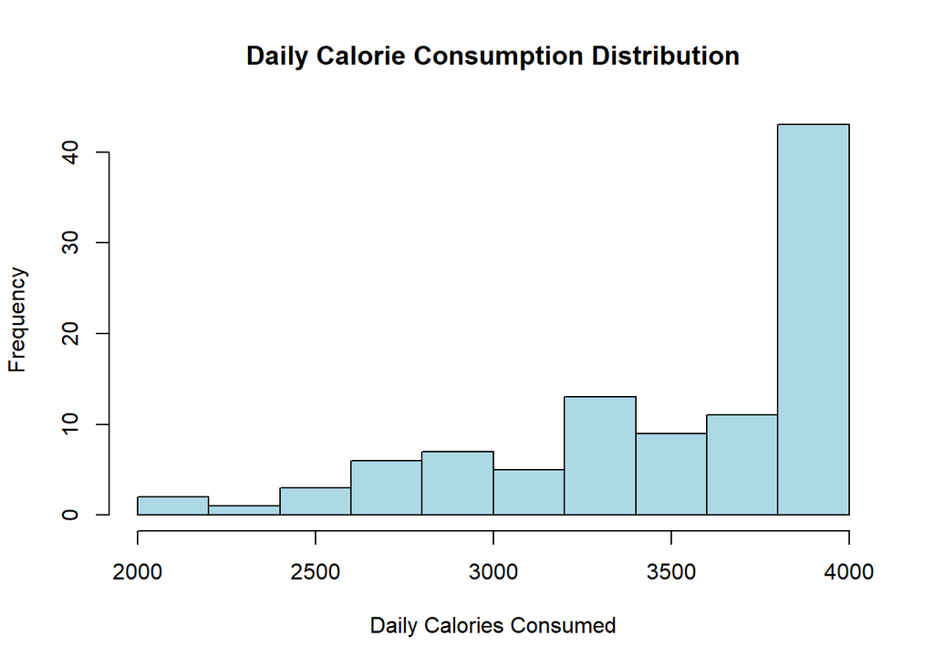

```r
hist(diet_csv$Daily.Calories.Consumed , breaks = 10 ,col = "lightblue" ,
     main = "Daily Calorie Consumption Distribution", xlab = "Daily Calories Consumed")
```

#Plot distribution of daily caloric surplus/deficit to check for skewness and normality.

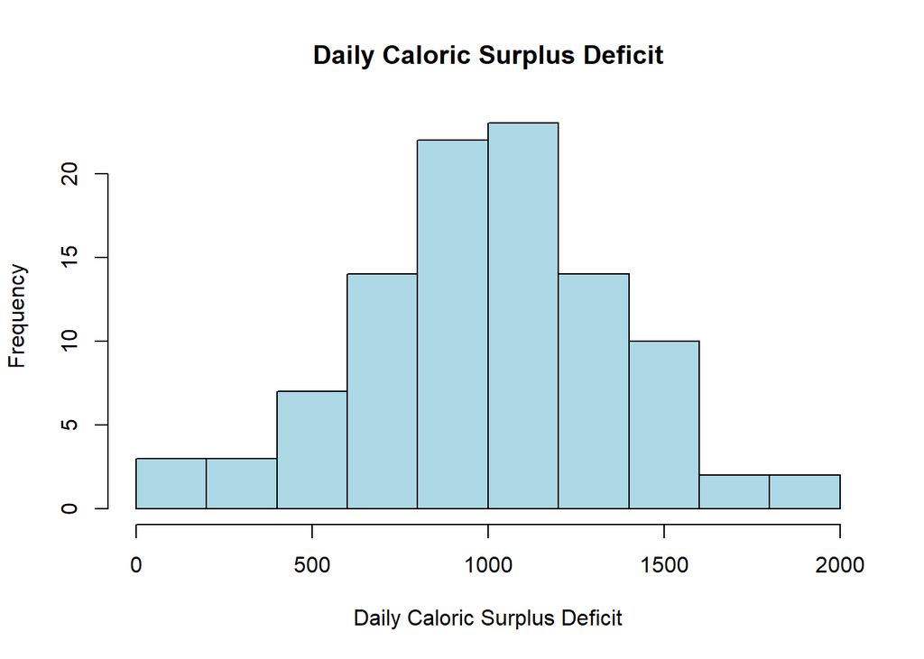

```r
hist(diet_csv$Daily.Caloric.Surplus.Deficit, col = "lightblue",
     main = "Daily Caloric Surplus Deficit" , xlab = "Daily Caloric Surplus Deficit")
```

#Plot distribution of final weight to check for skewness and normality.

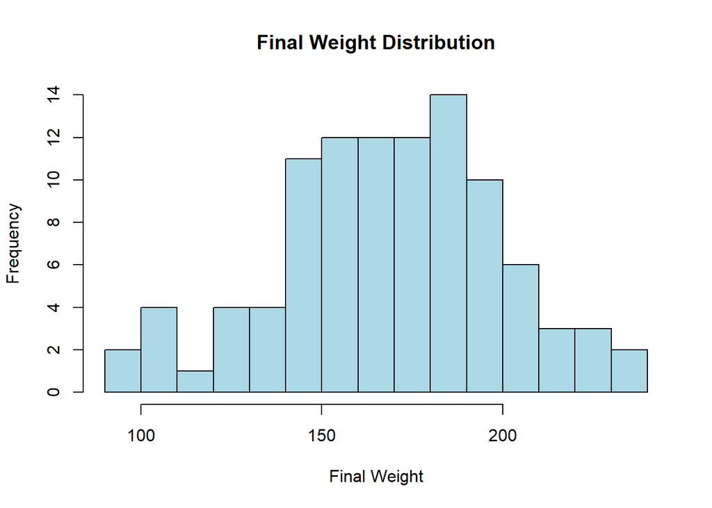

```r
hist(diet_csv$Final.Weight..lbs., col = "lightblue", main = "Final Weight Distribution",
     xlab = "Final Weight", breaks = 15)
```

#Examining parameters in relationship

```r
model_calorie <- lm(Daily.Caloric.Surplus.Deficit ~ BMR..Calories. +
                      Daily.Calories.Consumed, data = diet_csv)
summary(model_calorie)
```

```
##
## Call:
## lm(formula = Daily.Caloric.Surplus.Deficit ~ BMR..Calories. +
##     Daily.Calories.Consumed, data = diet_csv)
##
## Residuals:
##       Min        1Q    Median        3Q       Max
## -0.112826 -0.008605 -0.003486  0.000028  0.098454
##
## Coefficients:
##                           Estimate Std. Error   t value Pr(>|t|)
## (Intercept)              4.166e-02  3.131e-02      1.33    0.186
## BMR..Calories.          -1.000e+00  1.572e-05 -63601.40   <2e-16 ***
## Daily.Calories.Consumed  1.000e+00  1.116e-05  89583.44   <2e-16 ***
## ---
## Signif. codes:  0 '***' 0.001 '**' 0.01 '*' 0.05 '.' 0.1 ' ' 1
##
## Residual standard error: 0.04125 on 97 degrees of freedom
## Multiple R-squared:      1,  Adjusted R-squared:      1
## F-statistic: 4.016e+09 on 2 and 97 DF,  p-value: < 2.2e-16
```

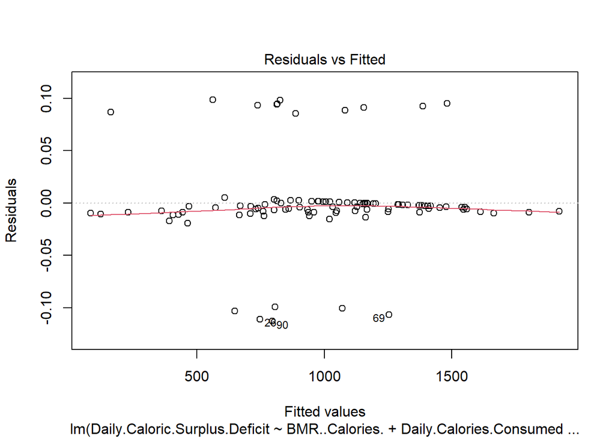

```r
plot(model_calorie, which = 1)
```

#Daily Caloric Surplus/Deficit=Daily Calories Consumed−BMR Calories #The nearly perfect fit (R-squared = 1) confirms that this formula fully explains the variance in the dependent variable, leaving almost no room for residual variation.

#Can Weight change be explained by age and sleep quality

```r
model_wc <- lm(Weight.Change..lbs. ~ Age + Sleep.Quality, data = diet_csv)
summary(model_wc)
```

```
##
## Call:
## lm(formula = Weight.Change..lbs. ~ Age + Sleep.Quality, data = diet_csv)
##
## Residuals:
##      Min       1Q   Median       3Q      Max
## -26.9853  -0.7542   0.9896   3.5548   7.9699
##
## Coefficients:
##                   Estimate Std. Error t value Pr(>|t|)
## (Intercept)        2.00500    2.63577   0.761    0.449
## Age               -0.01835    0.05037  -0.364    0.716
## Sleep.QualityFair -0.88046    1.93695  -0.455    0.650
## Sleep.QualityGood -0.41684    1.99080  -0.209    0.835
## Sleep.QualityPoor -9.96396    1.81913  -5.477 3.52e-07 ***
## ---
## Signif. codes:  0 '***' 0.001 '**' 0.01 '*' 0.05 '.' 0.1 ' ' 1
##
## Residual standard error: 5.972 on 95 degrees of freedom
## Multiple R-squared:  0.3823, Adjusted R-squared:  0.3563
## F-statistic:  14.7 on 4 and 95 DF,  p-value: 2.209e-09
```

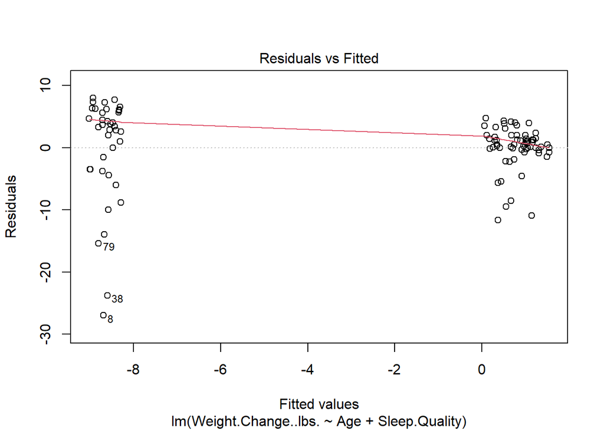

```r
plot(model_wc, which = 1)
```

#This suggests that individuals with poor sleep quality experience a significantly greater weight change (about 10 lbs less) compared to those with excellent sleep quality. And age does not matter in this data set.

#focusing on poor sleep quality

```r
diet_csv$PoorSleep <- ifelse(diet_csv$Sleep.Quality == "Poor", 1,0)

model_poor_sleep <- lm(Weight.Change..lbs. ~ Stress.Level * PoorSleep, data = diet_csv)
summary(model_poor_sleep)
```

```
##
## Call:
## lm(formula = Weight.Change..lbs. ~ Stress.Level * PoorSleep,
##     data = diet_csv)
##
## Residuals:
##      Min       1Q   Median       3Q      Max
## -19.8071  -1.6358   0.3789   2.4212  14.4767
##
## Coefficients:
##                        Estimate Std. Error t value Pr(>|t|)
## (Intercept)              4.0206     1.2569   3.199  0.00187 **
## Stress.Level            -0.7141     0.2422  -2.949  0.00401 **
## PoorSleep               -2.2874     2.2369  -1.023  0.30909
## Stress.Level:PoorSleep  -1.2419     0.3983  -3.118  0.00240 **
## ---
## Signif. codes:  0 '***' 0.001 '**' 0.01 '*' 0.05 '.' 0.1 ' ' 1
##
## Residual standard error: 4.877 on 96 degrees of freedom
## Multiple R-squared:  0.5838, Adjusted R-squared:  0.5708
## F-statistic: 44.88 on 3 and 96 DF,  p-value: < 2.2e-16
```

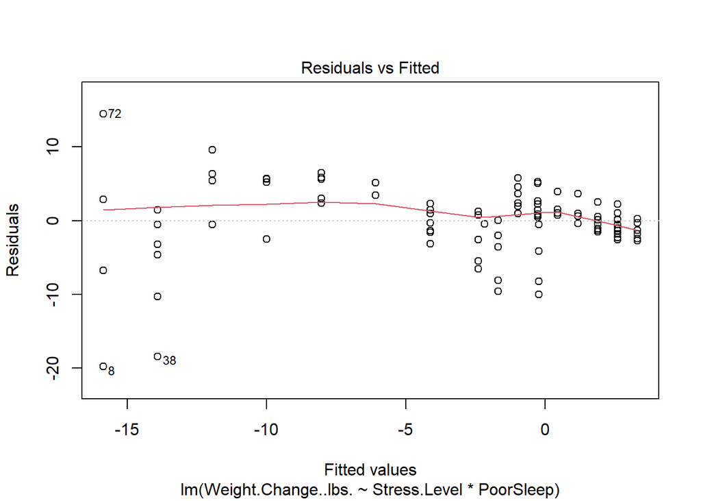

```r
plot(model_poor_sleep,which = 1)
```

#Stress Level has a significant impact on weight change, with higher stress levels leading to greater weight loss. #Poor Sleep Quality alone does not have a statistically significant effect, but it amplifies the negative impact of stress levels on weight change (as shown by the significant interaction term). #This suggests that the combination of high stress and poor sleep quality is particularly detrimental to weight maintenance or gain.

#Visualize the interaction effect of stress level and poor sleep on weight change.

```r
install.packages("interactions")
library(interactions)
```

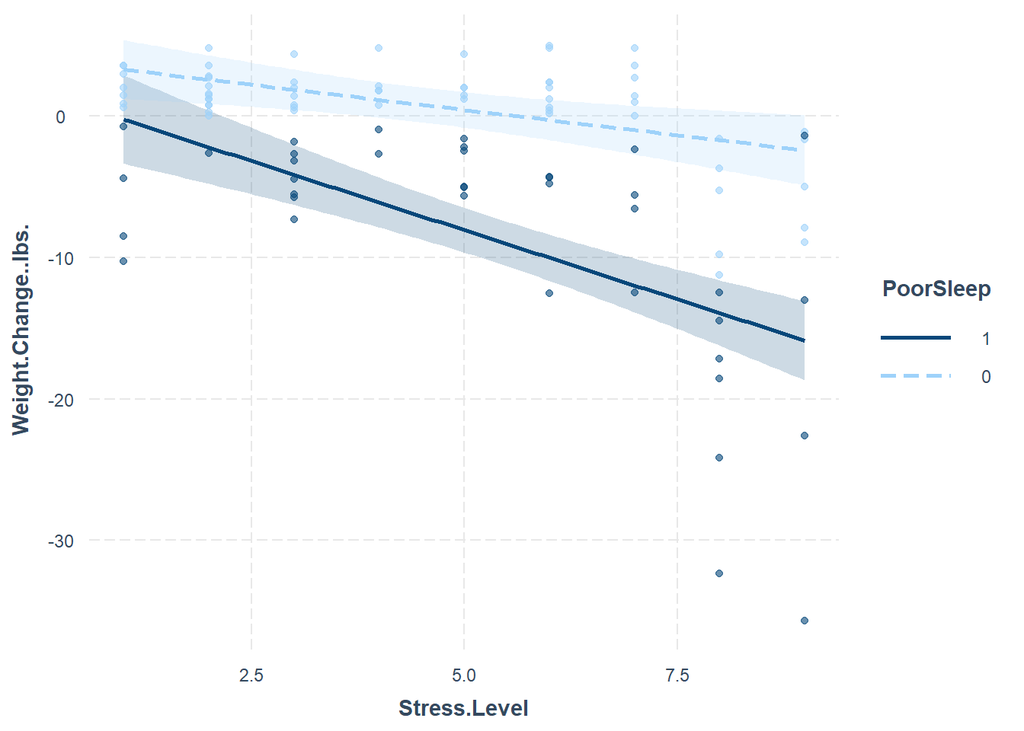

```r
interact_plot (model_poor_sleep,pred = Stress.Level , modx = PoorSleep,
              interval = TRUE, plot.points = TRUE)
```

## CONCLUSION

The analysis conducted on this dataset provides valuable insights into the relationships between various factors and weight change. Here are the key findings:

Age and Gender: Neither age nor gender was found to have a significant impact on weight change within this dataset.

Physical Activity: Despite existing research showing the positive impact of physical activity on weight management, no significant relationship was observed in this sample. This discrepancy may be due to the small sample size.

Sample Size Limitations: The dataset used in this study included only 100 individuals, which limits the generalizability of the findings. Small sample sizes are more prone to statistical variability, and results should be interpreted with caution.